# Introduction to Using R

January 12, 2021

## Data for Today

Data were collected on 344 penguins living on three islands (Torgersen, Biscoe, and Dream) in the Palmer Archipelago, Antarctica. In addition to which island each penguin lives on, the data contains information on the species of the penguin (Adelie, Chinstrap, or Gentoo), its bill length, bill depth, and flipper length (measured in millimeters), its body mass (measured in grams), and the sex of the penguin (female or male).

**What would the dataframe look like?**

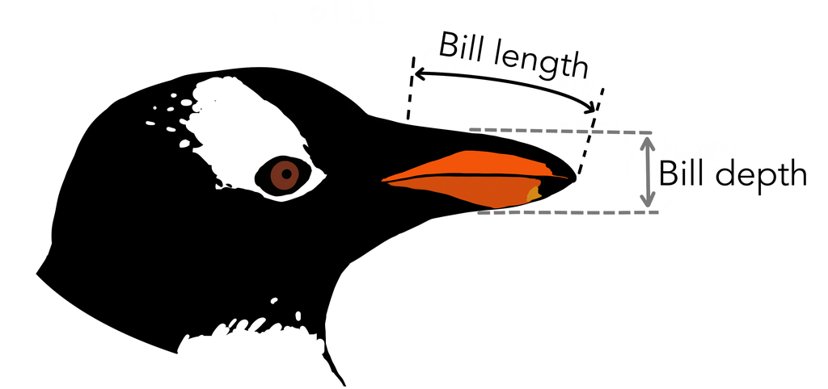

## Data Preview

```r
glimpse(penguins)
```

```
## Rows: 344
## Columns: 8
## $ species           <fct> Adelie, Adelie, Adelie, Adelie, Adelie, Adelie, Ade…
## $ island            <fct> Torgersen, Torgersen, Torgersen, Torgersen, Torgers…
## $ bill_length_mm    <dbl> 39.1, 39.5, 40.3, NA, 36.7, 39.3, 38.9, 39.2, 34.1,…
## $ bill_depth_mm     <dbl> 18.7, 17.4, 18.0, NA, 19.3, 20.6, 17.8, 19.6, 18.1,…
## $ flipper_length_mm <int> 181, 186, 195, NA, 193, 190, 181, 195, 193, 190, 18…
## $ body_mass_g       <int> 3750, 3800, 3250, NA, 3450, 3650, 3625, 4675, 3475,…
## $ sex               <fct> male, female, female, NA, female, male, female, mal…
## $ year              <int> 2007, 2007, 2007, 2007, 2007, 2007, 2007, 2007, 200…
```

## Data Wrangling

- Data Wrangling Verbs Used this Week
  - `filter()` – filter out/in observations/rows
  - `group_by()` – group data by a categorical variable
  - `count()` – counts the number of observations (rows) in different levels of a categorical variable

## What is the Pipe Operator?

- Clearly express a sequence of multiple operations
- **Improve code read-ability**

```r
penguins %>%
  filter(sex == "male", year == 2007) %>%
  group_by(species) %>%
  count()
```

```
## # A tibble: 3 x 2
## # Groups:   species [3]
##   species       n
##   <fct>     <int>
## 1 Adelie       22
## 2 Chinstrap    13
## 3 Gentoo       17
```

## Bivariate (Two Variables) Visualizations – For Numerical Data

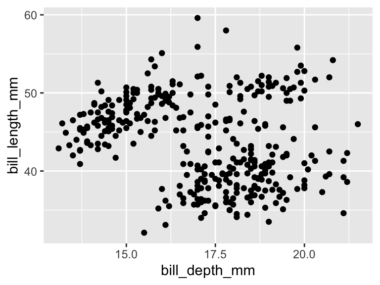

```r
penguins %>%
  ggplot(aes(y = bill_length_mm, x = bill_depth_mm)) +
  geom_point()
```

## Building a Blank `ggplot`

- `ggplot()` – a function to create the shell of a visualization
- `aes()` – maps variables to different aspects of the plot

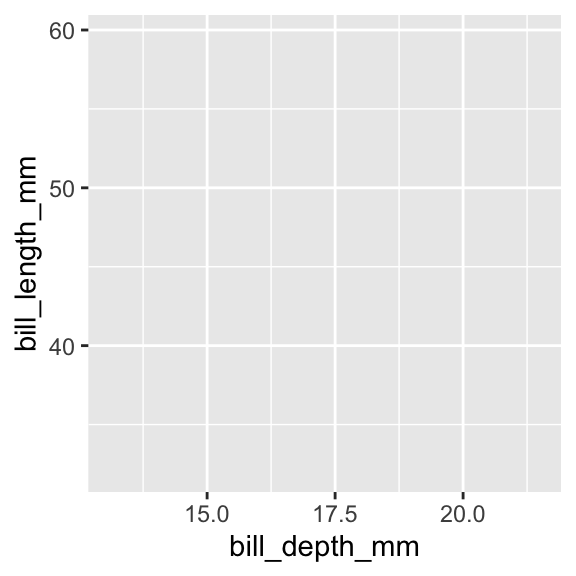

```r
penguins %>%
  ggplot(aes(y = bill_length_mm, x = bill_depth_mm))
```

## Adding a Geometric Object to the Plot

- `geom_XXX()`– tells ggplot how you want the data represented
- `geom_XXX()` is separated from `ggplot()` with a plus sign (`+`)

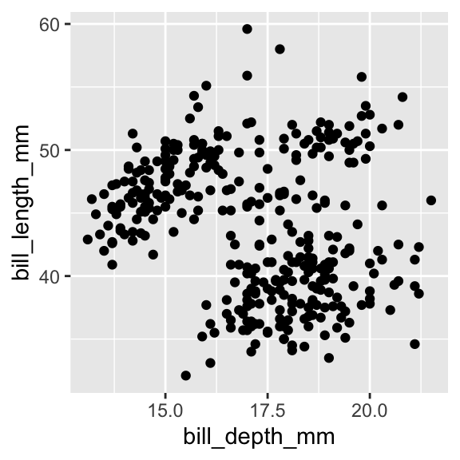

```r
penguins %>%
  ggplot(aes(y = bill_length_mm, x = bill_depth_mm)) +
  geom_point()
```

## Multivariate Plots

There are two main methods for adding a third (or fourth) variable into a data visualization.

This week we introduced the first method: **color**

- Mapping a variable to the `color` aesthetic in ggplot
  - creates colors for every level of a categorical variable
  - creates a gradient for different values of a quantitative variable

## Colors in Scatterplots

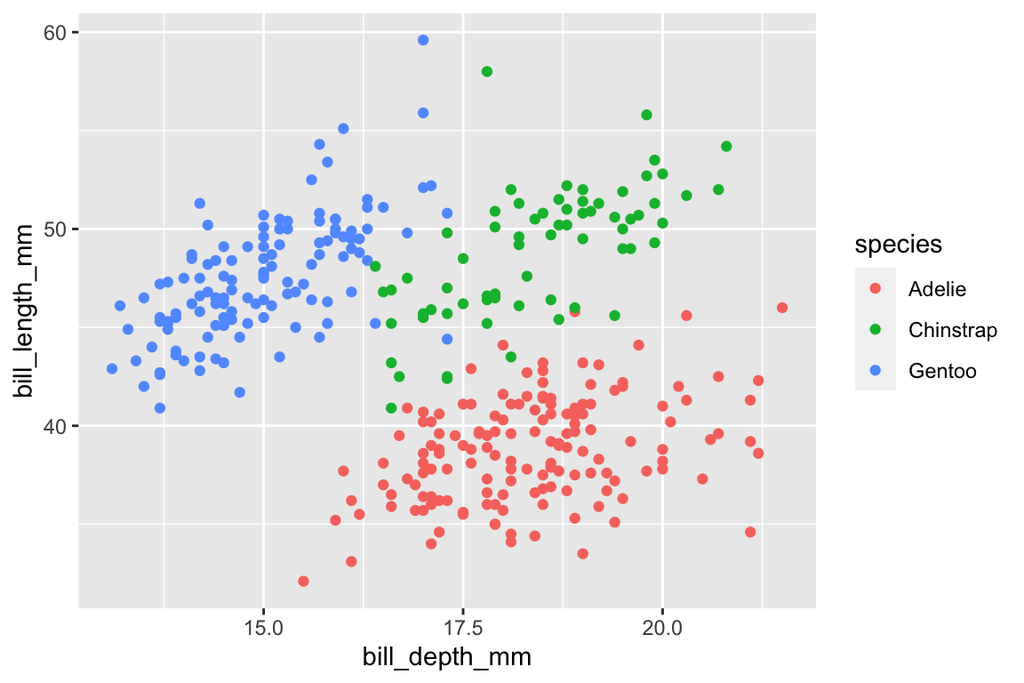

```r
penguins %>%
  ggplot(aes(y = bill_length_mm, x = bill_depth_mm, color = species)) +
  geom_point()
```

## Your Turn!

Suppose researchers were interested in investigating the relationship between a penguin’s flipper length and their year of capture, specifically for penguins from the Biscoe island.

They are also interested in how this relationship differs by penguin sex.

- **What data wrangling tasks are necessary to prepare the data for plotting?**
- **What visualization you believe would help address this question?**

## Solution?

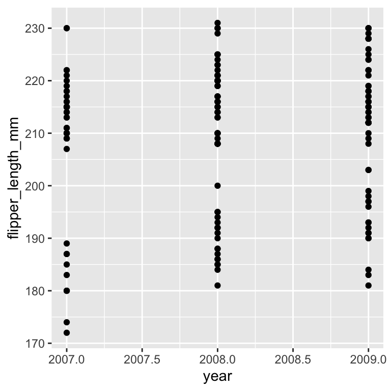

```r
penguins %>%
  filter(island == "Biscoe") %>%
  ggplot(aes(x = year, y = flipper_length_mm)) +
  geom_point()
```

## A Better Visualization?

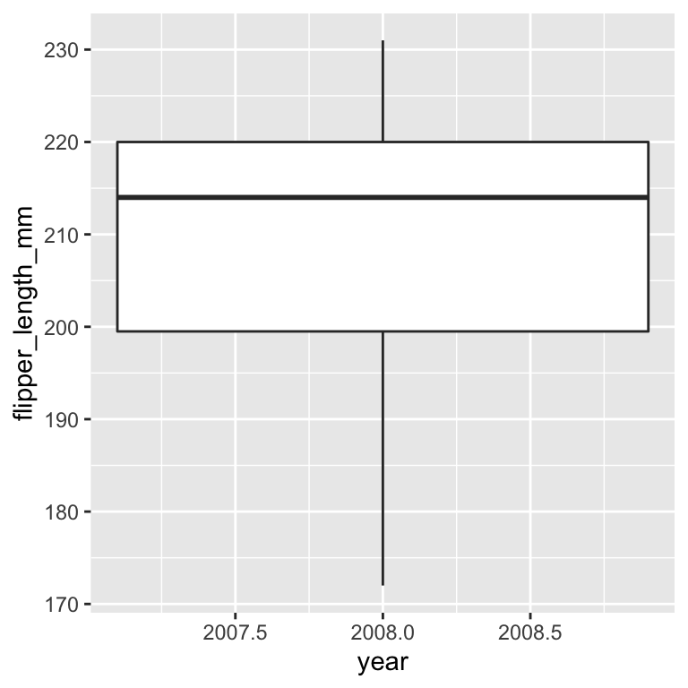

```r
penguins %>%
  filter(island == "Biscoe") %>%
  ggplot(aes(x = year, y = flipper_length_mm)) +
  geom_boxplot()
```

## A Much Better Visualization

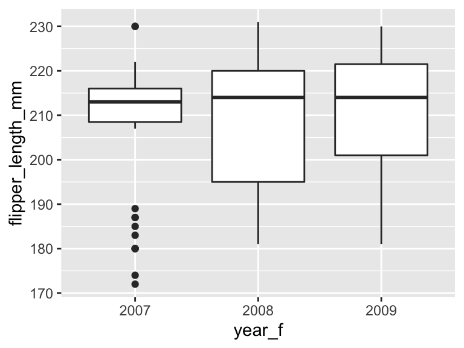

```r
penguins %>%
  filter(island == "Biscoe") %>%
  mutate(year_f = as.factor(year)) %>%
  ggplot(aes(x = year_f, y = flipper_length_mm)) +
  geom_boxplot()
```